# DSC 465, Homework 4

Kefu Zhu

04/17/2019

```r
# Load library
library(stats)
library(MASS)
library(partitionComparison)
library(latex2exp)
# Seed number for this assignment
my_seed = 007 # :o
```

# Question 1

```r
gem = read.table(file='GSE364n50.csv',sep=',',row.names=1,header=F)
```

## (a)

### (i)

```r
# Create the label vector
class = c(rep('positive',30),rep('negative',20))
# Perform the PCA on original dataset
PCA_components = prcomp(gem, center = TRUE, scale = FALSE)$x
# Construct a QDA classifier
fit.qda = qda(PCA_components[,1:4], grouping = class, prior = c(0.5,0.5), CV = TRUE)
```

```r
# Original class proportion
table(class)/length(class)
```

```
## class
## negative positive
##      0.4      0.6
```

**Answer**:

If the prior probabilities are not specified, the original class proportion will be used, which is `(0.4,0.6)` in this case.

### (ii)

```r
# Obtain the posterior probability for positive class
pred = fit.qda$posterior[,'positive']
# Convert the probability to TRUE/FALSE vector (class == 'positive')
pred = pred > 0.5
# TRUE/FALSE vector for ground truth
truth = class == 'positive'
# TRUE/FALSE vector for correctly classified data
pred_correct = pred == truth
# Obtain the maximum posterior probability for each data point
p_max = apply(fit.qda$posterior, 1, max) # 1 means obtaining the maximum number by row
```

```r
# Classification result for observations with p_max >= 0.75
pred_upper_25 = pred_correct[p_max >= 0.75]
# Correct classification rate
sum(pred_upper_25)/length(pred_upper_25)
```

```
## [1] 0.8974359
```

```r
# Classification result for observations with p_max < 0.75
pred_lower_75 = pred_correct[p_max < 0.75]
# Correct classification rate
sum(pred_lower_75)/length(pred_lower_75)
```

```
## [1] 0.6363636
```

```r
# p_max for correctly classified observations
pred_correct_posterior = p_max[pred_correct]
# p_max for wrongly classified observations
pred_wrong_posterior = p_max[!pred_correct]
# Wilcoxon rank-sum test
wilcox.test(pred_correct_posterior, pred_wrong_posterior)
```

```
##
##  Wilcoxon rank sum test
##
## data:  pred_correct_posterior and pred_wrong_posterior
## W = 260, p-value = 0.01336
## alternative hypothesis: true location shift is not equal to 0
```

**Answer**:

- **What is the correct classification rate for observations with $p_{max} \ge 0.75$?**

  Correct classification rate = 0.8974359
- **What is the correct classification rate for observations with $p_{max} < 0.75$?**

  Correct classification rate = 0.6363636
- **Wilcoxon rank sum test**

  Because p-value from the test is 0.0133598, which is smaller than $0.05$, we conclude that there is a statistically significant difference in the distribution of $p_{max}$ between observations that were correctly classified and those that weren’t.

### (iii)

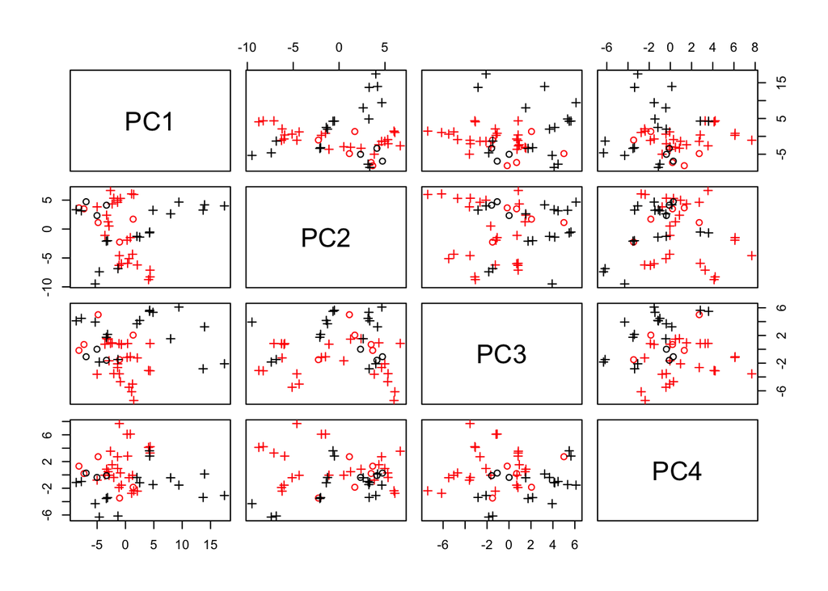

```r
# Create the color vector
#   Black: -ve (non-metastatic)
#   Red: +ve (metastatic)
col_index = as.numeric(truth) + 1
col_vector = c('black','red')[col_index]
# Create the pch vector
#   o: Incorrectly classified (pch = 1)
#   +: Correctly classified (pch = 3)
pch_index = as.numeric(pred_correct) + 1
pch_vector = c(1,3)[pch_index]
# Pairwise scatterplots of first four PCA components
pairs(PCA_components[,1:4], col = col_vector, pch = pch_vector)
```

**Answer**:

- Correctly classified observations are quite spread out in each scatterplot, which means the values of principal components varies quite uniformly for these obverstaions.
- Incorrectly classified observations tend to have
  - low values on `PC1`
  - high values on `PC2` and `PC3`

## (b)

### Method 1

```r
# Initialize empty vector to store CE value for method 1
CE_1 = c()
# Start time
start = Sys.time()
# Fit qda model with different number of PCA components
for(K in seq(1,18)){
  # When K = 1, the object is not a matrix, force it XD
  if(K == 1){
    tmp.qda = qda(matrix(PCA_components[,1:K]), grouping = class)
  } else{
    tmp.qda = qda(PCA_components[,1:K], grouping = class)
  }
  # Prediction by LOOCV
  pred = predict(tmp.qda, method = 'looCV')$class
  # Convert prediction to TRUE/FALSE vector
  pred_bool = pred == 'positive'
  # Compute the classifcation error rate and append it to the vector
  CE_1 = c(CE_1, sum(pred_bool != truth)/length(truth))
}
```

### Method 2

```r
# Initialize empty vector to store CE value for method 2
CE_2 = c()
# Fit qda model with different number of PCA components
for(K in seq(1,18)){
  # Initialize the counter for the correct prediction
  running_incorrect = 0
  # Pick each data point as testing set and perform PCA on the rest
  for(i in 1:nrow(gem)){
    # Test data point (test set)
    test = gem[i,]
    # True class for test data point
    class_i = class[i]
    # Perform PCA on the rest data (train set)
    train_PCA = prcomp(gem[-i,])
    # Extract the components from PCA
    train_PCA_components = train_PCA$x
    # When K = 1, the object is not a matrix, force it XD
    if(K == 1){
      tmp.qda = qda(matrix(train_PCA_components[,1:K]), grouping = class[-i])
    } else{
      tmp.qda = qda(train_PCA_components[,1:K], grouping = class[-i])
    }
    # Project the test set into PCA space calcualted on the train set
    test_PCA_components = predict(train_PCA,test)
    # Prediction on the test set
    test_pred = predict(tmp.qda, test_PCA_components[1:K])$class
    # If the prediction on test set is incorrect
    if(class_i != test_pred){
      # Increment the correct counter
      running_incorrect = running_incorrect + 1
    }
  }
  # Compute the classifcation error rate and append it to the vector
  CE_2 = c(CE_2, running_incorrect/nrow(gem))
  # Print the progress
  print(sprintf('Experiment with K = %i is done...',K))
}
```

```
## [1] "Experiment with K = 1 is done..."
## [1] "Experiment with K = 2 is done..."
## [1] "Experiment with K = 3 is done..."
## [1] "Experiment with K = 4 is done..."
## [1] "Experiment with K = 5 is done..."
## [1] "Experiment with K = 6 is done..."
## [1] "Experiment with K = 7 is done..."
## [1] "Experiment with K = 8 is done..."
## [1] "Experiment with K = 9 is done..."
## [1] "Experiment with K = 10 is done..."
## [1] "Experiment with K = 11 is done..."
## [1] "Experiment with K = 12 is done..."
## [1] "Experiment with K = 13 is done..."
## [1] "Experiment with K = 14 is done..."
## [1] "Experiment with K = 15 is done..."
## [1] "Experiment with K = 16 is done..."
## [1] "Experiment with K = 17 is done..."
## [1] "Experiment with K = 18 is done..."
```

```r
# End time
end = Sys.time()
# Run time
print(end-start)
```

```
## Time difference of 2.6497 mins
```

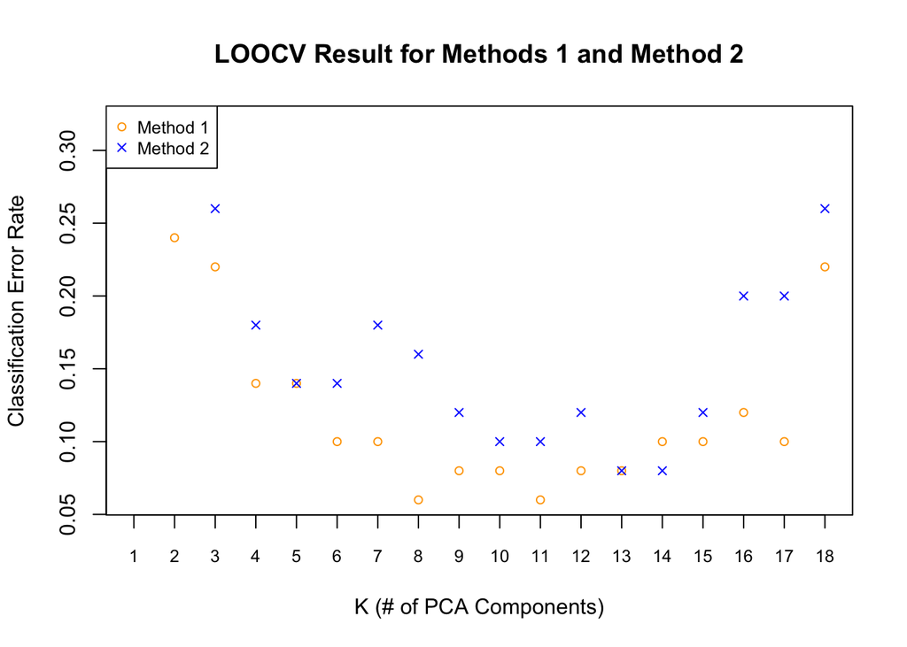

```r
# Plot
matplot(x = seq(1,18), y = cbind(CE_1,CE_2), xaxt = 'n',
        pch = c(1,4), col = c('orange','blue'), cex = 0.8,
        xlab = 'K (# of PCA Components)', ylab = 'Classification Error Rate',
        main = 'LOOCV Result for Methods 1 and Method 2')
# Add ticks to x-axis
axis(side = 1, at = seq(1,18), cex.axis = 0.8)
# Add legend
legend('topleft',
        legend = c('Method 1','Method 2'),
        col = c('orange','blue'),
        pch = c(1,4),
        cex = 0.8)
```

**Answer**:

- **How do the methods compare?**

  Because the PCA components used to train the QDA model in Method 1 have already taken the test set into consideration, in general, Method 1 yields higher classfication rate than Method 2
- **What would be the recommended number of principal components $K$?**

  Based on the graph above, the first $13$ principal components seems to be a good number to use based on the experiment result from both methods.

# Question 2

## (a)

```r
pp = new("Partition", c(1,1,2,2))
qq = new("Partition", c(1,1,2,3))
mutualInformation(pp,qq)
```

```
## [1] 0.6931472
```

## (b)

```r
# Extract the feature set
iris_feature = iris[,-5]
# Hierarchical cluster
fit.hclust = hclust(dist(as.matrix(iris_feature)), method = 'average')
```

## (c)

```r
# Calculate the distance between two clusters
average_distance = function(cluster_1_index, cluster_2_index, distance_matrix){
  # cluster_1_index: the index of data point that belongs to cluster 1
  # cluster_2_index: the index of data point that belongs to cluster 2
  # distance_matrix: the original distance matrix (calculated in Euclidean distance) for Hierarchical clustering

  # Total number of pairs of data points between two clusters
  total_pairs = length(cluster_1_index)*length(cluster_2_index)
  # Initialize a variable to store the total distance:
  #     sum of distances for each pairs of data points
  total_distance = 0

  # Loop through every pair of data points
  for (i in cluster_1_index){
    for (j in cluster_2_index){
      # Add the distance between this pair of data to the total_distance
      total_distance = total_distance + distance_matrix[i,j]
    }
  }

  # Return the average distance between two clusters
  return(total_distance/total_pairs)
}
```

```r
# The distance matrix
d_matrix = as.matrix(dist(as.matrix(iris_feature)))
# Different number of clusters
for(cluster in 2:10){
  # Create variable on the fly (e.g. distance_1)
  # Initialize the distance matrix
  assign(paste('distance_',cluster,sep=''), matrix(rep(NA,cluster^2), nrow = cluster))
  # Create a temporary deep copy of the distance matrix
  tmp_matrix = get(paste('distance_',cluster,sep=''))
  # Perform hierarchical clustering with k = cluster
  tmp_cluster = cutree(fit.hclust, k = cluster)
  # Compute the distance between each cluster
  for(i in 1:(cluster-1)){
    for(j in i+1:cluster){
      # Prevent j from going out of scope
      if(j <= cluster){
        # Distance between cluster and itself should not be calculated
        if(i != j){
        # Extract the index of data points belongs to the ith cluster
        cluster_i_index = which(tmp_cluster == i)
        # Extract the index of data points belongs to the jth cluster
        cluster_j_index = which(tmp_cluster == j)
        # Compute the average distance between ith cluster and jth cluster
        tmp_average_distance = average_distance(cluster_i_index,cluster_j_index, d_matrix)
        # Add the computed distance to the distance matrix
        tmp_matrix[i,j] = tmp_average_distance
        tmp_matrix[j,i] = tmp_average_distance
        # Overwrite the original distance matrix with the calculated temporary matrix
        assign(paste('distance_',cluster,sep=''), tmp_matrix)
        }
      }
    }
  }
}
```

```r
# Initialize a vector to store the smallest cluster distance for each K
min_dist_list = c()
# Determine the smallest cluster distance for each K
for(k in 2:10){
  # Extract the smallest cluster distance for current K
  min_dist = min(get(paste('distance_',k,sep='')), na.rm = TRUE)
  # Append it to the vector
  min_dist_list = c(min_dist_list, min_dist)
  # Print
  print(sprintf('Smallest cluster distance when K = %i: %f',k,min_dist))
}
```

```
## [1] "Smallest cluster distance when K = 2: 4.062683"
## [1] "Smallest cluster distance when K = 3: 1.963614"
## [1] "Smallest cluster distance when K = 4: 1.785566"
## [1] "Smallest cluster distance when K = 5: 1.380994"
## [1] "Smallest cluster distance when K = 6: 1.314188"
## [1] "Smallest cluster distance when K = 7: 1.186779"
## [1] "Smallest cluster distance when K = 8: 1.090053"
## [1] "Smallest cluster distance when K = 9: 1.069208"
## [1] "Smallest cluster distance when K = 10: 1.059788"
```

## (d)

```r
# Calcualte the cluster similarity between two clustering
cluster_similarity = function(Q,R){
  require(partitionComparison)
  # Create partition objects
  qq = new('Partition', Q)
  rr = new('Partition', R)
  # Calculate entropy for both partition
  entropy_Q = mutualInformation(qq,qq)
  entropy_R = mutualInformation(rr,rr)
  # Calculate mutual information between two partition
  MI = mutualInformation(qq,rr)
  # Calculate the cluster similarity
  similarity = MI/max(entropy_Q, entropy_R)

  return(similarity)
}
```

```r
# Initialize a vector to store the smallest cluster distance for each K
cluster_similarity_list = c()
# Different number of clusters
for(cluster in 2:10){
  # Perform hierarchical clustering with k = cluster
  tmp_cluster = cutree(fit.hclust, k = cluster)
  # Compute the cluster similarity between current clustering result and ground truth
  similarity = cluster_similarity(tmp_cluster, as.numeric(iris$Species))
  # Append it to the vector
  cluster_similarity_list = c(cluster_similarity_list, similarity)
}
```

## (e)

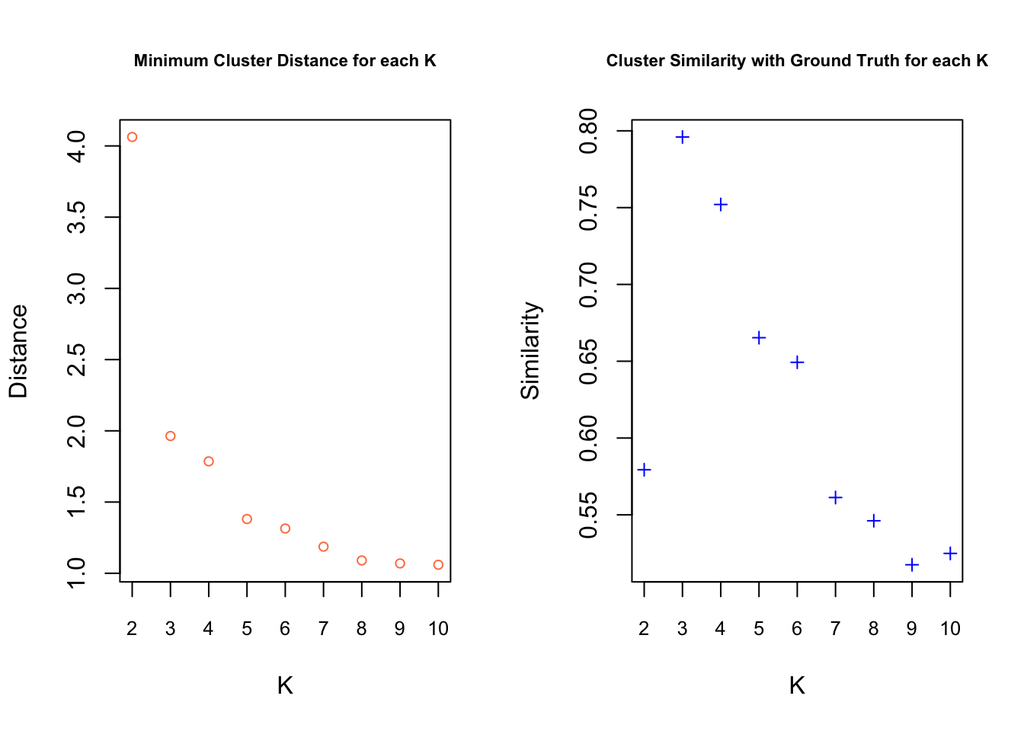

```r
# Set 1x2 graph grid
par(mfrow=c(1,2))
# Plot minnimum cluster distance vs. K
plot(x = seq(2,10), y = min_dist_list, pch = 1, col = 'coral', cex = 0.8, cex.main = 0.7,
     xaxt = 'n', xlab = 'K', ylab = 'Distance',
     main = 'Minimum Cluster Distance for each K')
# Add ticks to x-axis
axis(side = 1, at = seq(2,10), cex.axis = 0.8)
# Plot cluster similarity vs. K
plot(x = seq(2,10), y = cluster_similarity_list, pch = 3, col = 'blue', cex = 0.8,
     cex.main = 0.7, xaxt = 'n', xlab = 'K', ylab = 'Similarity',
     main = 'Cluster Similarity with Ground Truth for each K')
# Add ticks to x-axis
axis(side = 1, at = seq(2,10), cex.axis = 0.8)
```

```r
# K = 3
hclust_3 = cutree(fit.hclust, k = 3)
# Accuracy
acc = sum(hclust_3 == as.numeric(iris$Species))/nrow(iris) * 100
acc
```

```
## [1] 90.66667
```

**Answer**:

If we pick the number of clusters based on the smallest cluster distance, we may pick either $2$ or $3$, which is really close to the ground truth.

If we calculate the accuracy of clustering when $K = 3$, we may find out the hierarchical clustering did really good with $accuracy =$ 90.6666667

AMAZING! 🤟

# Question 3

```r
# Extract 2-10 columns from UScereal and perform transformation log_10(x+1)
log_UScereal = log(UScereal[,2:10]+1, base = 10)
# Drop the 8th column (orignal 9th column)
log_UScereal = log_UScereal[,-8]
```

## (a)

```r
# Initialize empty vector to store SSW for each value of K
SSW = c()
# Fit kmeans model with different number of clusters
for(K in seq(1,15)){
  # Set seed
  set.seed(my_seed)
  # Perform kmeans on the data with K clusters
  fit.kmeans = kmeans(log_UScereal, centers = K, nstart = 100)
  # Append the SSW value of current kmeans model to the vector
  SSW = c(SSW, fit.kmeans$tot.withinss)
}
# Obtain the SST
# Note: (The SST is the same across all models since the training dataset remains the same)
SST = fit.kmeans$totss
# Calculate the r-squared
r_squared = 1 - (SSW/SST)
```

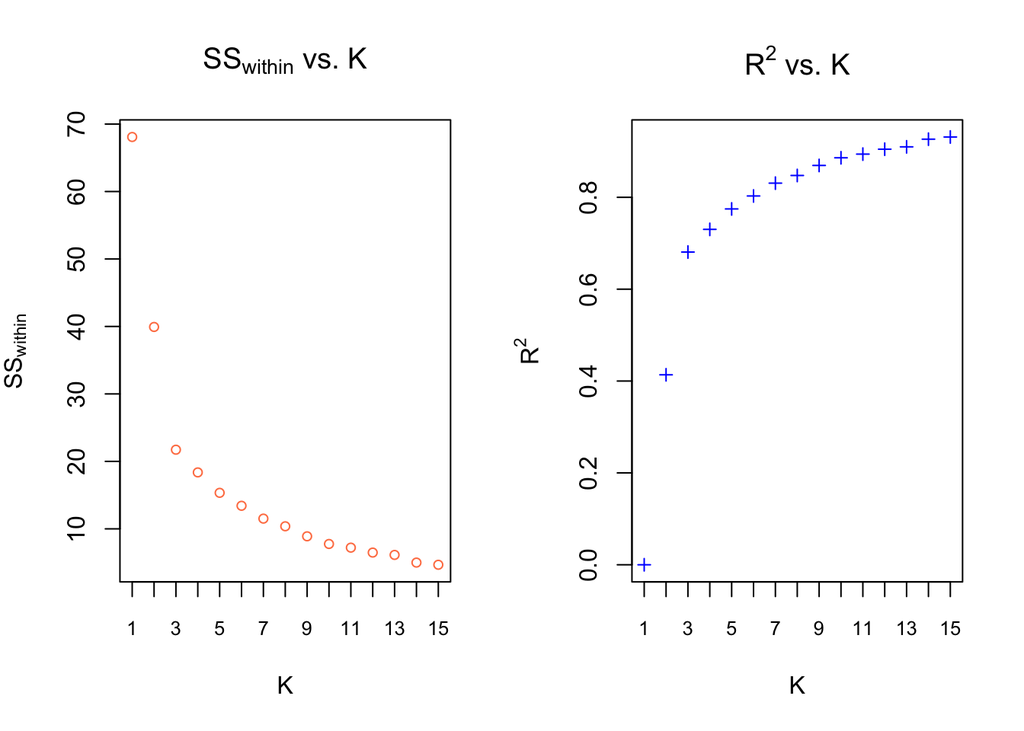

```r
# Set 1x2 graph grid
par(mfrow=c(1,2))
# Plot SSW vs. K
plot(x = seq(1,15), y = SSW, pch = 1, col = 'coral', cex = 0.8, xaxt = 'n',
     xlab = 'K', ylab = TeX('SS_{within}'), main = TeX('SS_{within} vs. K'))
# Add ticks to x-axis
axis(side = 1, at = seq(1,15), cex.axis = 0.8)
# Plot r-squared vs. K
plot(x = seq(1,15), y = r_squared, pch = 3, col = 'blue', cex = 0.8, xaxt = 'n',
     xlab = 'K', ylab = TeX('R^2'), main = TeX('R^2 vs. K'))
# Add ticks to x-axis
axis(side = 1, at = seq(1,15), cex.axis = 0.8)
```

**Answer**:

As shown in the graphs above, both $SS_{within}$ and $R^2$ seem to converge after $K=12$. Specifically, when $K=12$, $R^2 =$ 0.9047673.

Because the kmeans model already captures the majority of the variations in the dataset with $12$ clusters. There is no need to add more complexity to the model that may leads to overfitting.

Therefore, $12$ is a good estimate of the number of actual clusters.

## (b)

```r
# Obtain the change in r-squared as K changes
r_squared.changes = (r_squared[-1] - r_squared[-15])
# Return the index of the first change that is smaller than 0.1
which(r_squared.changes < 0.1)[1]
```

```
## [1] 3
```

```r
# Set seed
set.seed(my_seed)
# Perform kmeans on the data with 3 clusters
fit.kmeans = kmeans(log_UScereal, centers = 3, nstart = 100)
```

```r
# Brand names in cluster #1
names(fit.kmeans$cluster)[fit.kmeans$cluster == 1]
```

```
##  [1] "Apple Cinnamon Cheerios" "Apple Jacks"
##  [3] "Cap'n'Crunch"            "Cheerios"
##  [5] "Cinnamon Toast Crunch"   "Cocoa Puffs"
##  [7] "Corn Chex"               "Corn Flakes"
##  [9] "Corn Pops"               "Count Chocula"
## [11] "Crispix"                 "Double Chex"
## [13] "Froot Loops"             "Frosted Flakes"
## [15] "Fruity Pebbles"          "Golden Crisp"
## [17] "Golden Grahams"          "Grape Nuts Flakes"
## [19] "Honey Graham Ohs"        "Honey-comb"
## [21] "Kix"                     "Lucky Charms"
## [23] "Multi-Grain Cheerios"    "Nut&Honey Crunch"
## [25] "Product 19"              "Rice Chex"
## [27] "Rice Krispies"           "Smacks"
## [29] "Special K"               "Total Corn Flakes"
## [31] "Total Whole Grain"       "Triples"
## [33] "Trix"                    "Wheaties"
## [35] "Wheaties Honey Gold"
```

```r
# Brand names in cluster #2
names(fit.kmeans$cluster)[fit.kmeans$cluster == 2]
```

```
##  [1] "100% Bran"
##  [2] "All-Bran"
##  [3] "All-Bran with Extra Fiber"
##  [4] "Basic 4"
##  [5] "Bran Chex"
##  [6] "Bran Flakes"
##  [7] "Clusters"
##  [8] "Cracklin' Oat Bran"
##  [9] "Crispy Wheat & Raisins"
## [10] "Fruit & Fibre: Dates Walnuts and Oats"
## [11] "Fruitful Bran"
## [12] "Grape-Nuts"
## [13] "Great Grains Pecan"
## [14] "Honey Nut Cheerios"
## [15] "Just Right Fruit & Nut"
## [16] "Life"
## [17] "Mueslix Crispy Blend"
## [18] "Nutri-Grain Almond-Raisin"
## [19] "Oatmeal Raisin Crisp"
## [20] "Post Nat. Raisin Bran"
## [21] "Quaker Oat Squares"
## [22] "Raisin Bran"
## [23] "Raisin Nut Bran"
## [24] "Total Raisin Bran"
## [25] "Wheat Chex"
```

```r
# Brand names in cluster #3
names(fit.kmeans$cluster)[fit.kmeans$cluster == 3]
```

```
## [1] "Frosted Mini-Wheats"       "Puffed Rice"
## [3] "Raisin Squares"            "Shredded Wheat 'n'Bran"
## [5] "Shredded Wheat spoon size"
```

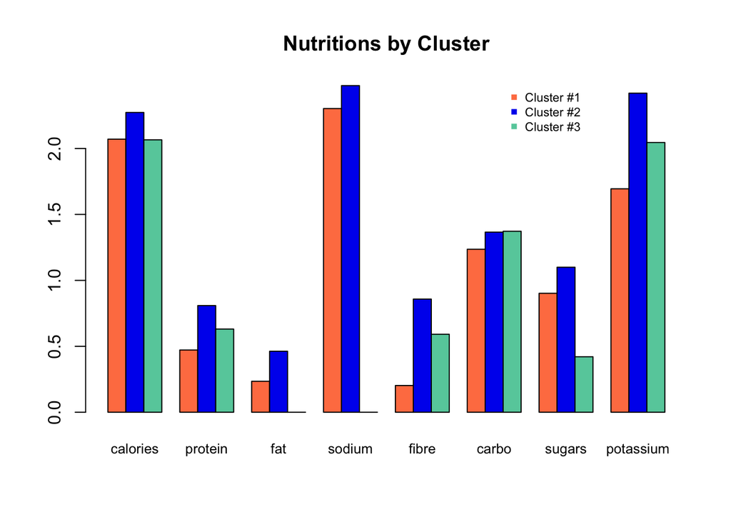

```r
# Barplot
barplot(fit.kmeans$centers, beside = T, col = c('coral','blue2','aquamarine3'),
        names.arg = colnames(log_UScereal), cex.names = 0.8, main = 'Nutritions by Cluster')
# Add legend
legend(x = 23, y = 2.5, c('Cluster #1','Cluster #2','Cluster #3'), pch=15, cex = 0.7,
       col = c('coral','blue2','aquamarine3'), bty="n")
```

**Answer**:

# Question 4

## (a)

As shown in the problem, we know

$MI(A,B) = H(P_A) + H(P_B) - H(P_{AB})$

$H(P_{AB}) = -\sum_{i=1}^n \sum_{j=1}^m p_{ij} log_b p_{ij}, H(P_A) = - \sum_{i=1}^n \alpha_i log_b\alpha_i, H(P_B) = - \sum_{j=1}^m \beta_i log_b\beta_i$

where $\alpha_i = \sum_{j=1}^m p_{ij}$ and $\beta_j = \sum_{i=1}^n p_{ij}$

Hence, we can derive that

$H(P_A) = -\sum_{i=1}^n \sum_{j=1}^m p_{ij} log_b \alpha_i,\ H(P_B) = -\sum_{i=1}^n \sum_{j=1}^m p_{ij} log_b \beta_j$

Therefore, we can represent $MI(A,B)$ as

$MI(A,B) = -\sum_{i=1}^n \sum_{j=1}^m p_{ij} log_b \frac{\alpha_i \beta_j}{p_{ij}}$

## (b)

Define $g(I,J) = \frac{\alpha_i \beta_j}{p_{ij}}$, for each pair of $i,j$

$P(-log_b(g(I,J)) = p_{ij})$

Then the we can now write $MI(A,B) = E[-log_b(g(I,J))]$

For every $(i_1,j_1)$ and $(i_2,j_2)$ where $i_1 \ne i_2, j_1 \ne j_2$ and $0 \le b \le 1$, we have

$b(-log_b g(i_1,j_1)) + (1-b)(-log_b g(i_2, j_2)) \ge -log_b[\ b \cdot g(i_1, j_2) + (1-b) \cdot g(i_2,j_2)\ ]$

Therefore, we can conclude that $-log_b(g(I,J))$ is a convex function

Which means that we now have $MI(A,B) \ge -log_b E[g(I,J)]$.

Because $E[g(I,J)] = \sum_{i=1}^n \sum_{j=1}^m p_{ij} \frac{\alpha_i \beta_j}{p_{ij}} = 1$, so we can easily notice that $MI(A,B) \ge 0$

## (c)

Since we already know $H(P_A) = - \sum_{i=1}^n p_{ij} log_b\alpha_i, H(P_{AB}) = -\sum_{i=1}^n \sum_{j=1}^m p_{ij} log_b p_{ij}$ from part(a), we can have

$H(P_A) - H(P_{AB}) = -\sum_{i=1}^n p_{ij} log_b\alpha_i + \sum_{i=1}^n \sum_{j=1}^m p_{ij} log_b p_{ij} = - \sum_{i=1}^n \sum_{j=1}^m p_{ij} log_b \frac{\alpha_i}{p_{ij}}$

$\because \alpha_i = \sum_{j=1}^m p_{ij}\ \therefore \frac{\alpha_i}{p_{ij}} \ge 1$

$\therefore H(P_A) - H(P_{AB}) = - \sum_{i=1}^n \sum_{j=1}^m p_{ij} log_b \frac{\alpha_i}{p_{ij}} \le 0$

Similarly, $H(P_B) - H(P_{AB}) = - \sum_{i=1}^n \sum_{j=1}^m p_{ij} log_b \frac{\beta_i}{p_{ij}} \le 0$

Then we can notice that

$MI(A,B) = H(P_A) + H(P_B) - H(P_{AB}) \le H(P_A)$

Similarly,

$MI(A,B) = H(P_A) + H(P_B) - H(P_{AB}) \le H(P_B)$

We can now denote $MI(A,B)$ as $MI(A,B) \le \min\{H(P_A), H(P_B)\}$

## (d)

The independent random selections from $A$ and $B$ implies that $p_{ij} = \alpha_i \beta_j$, so we can verify that the lower bound of $MI(A,B)$ can be attained

$MI(A,B) = -\sum_{i=1}^n \sum_{j=1}^m p_{ij} log_b 1$

## (e)

- Condition (i) tells us that for any row $i$ in Table 1, only one one entry meets the condition $p_{ij} = \alpha_i$, while all other $p_{ij}$ are zeros

  Therefore, we now have $MI(A,B) = -\sum_{i=1}^n \sum_{j=1}^m p_{ij} log_b \frac{\alpha_i \beta_j}{p_{ij}} = -\sum_{i=1}^n \sum_{j=1}^m p_{ij} log_b \beta_j = -\sum_{j=1}^m \beta_j log_b \beta_j = H(P_B)$

  $\therefore H(P_B) \le H(P_a)$
- Condition (ii) tells us that for each column $j$ in Table 1, only one entry meets the condition $p_{ij} = \beta_j$, while all other $p_{ij}$ are zeros

  Therefore, we now have $MI(A,B) = -\sum_{i=1}^n \sum_{j=1}^m p_{ij} log_b \frac{\alpha_i \beta_j}{p_{ij}} = -\sum_{i=1}^n \sum_{j=1}^m p_{ij} log_b \alpha_i = -\sum_{i=1}^n \alpha_i log_b \beta_j = H(P_A)$

  $\therefore H(P_A) \le H(P_B)$

To summarize, under condition (i) and (ii), we can obtain the upper bound of $MI(A,B)$

## (f)

Suppose we label the cluster in $Q$ with $\{1,2,...,M\}$ and $R$ with $\{1,2,...,N\}$ and we know $M < N$. In Table1, The row will indicate labels from cluster $Q$ and the column will indicate labels from cluster $R$.

Assume we use $\min\{H(P_A), H(P_B)\}$ as the normalization term in the denominator for computing the clustering similarity index, we would end up with $I(Q,R) = 1$. Since we already know $Q$ and $R$ are different, so $I(Q,R) = 1$ is definitely not a reasonable quantity to describe their similarity.

However, if we use $\max\{H(P_A), H(P_B)\}$ as the normalization term, we will get $I(Q,R) < 1$, which better describes the situation.